# Stat 467 project

2023-12-11

```r
library(MVN)
library(dplyr)
```

```r
library(corrplot)
library(factoextra)
library(psych)
library(car)
library(labeling)
library(GGally)
library(ICSNP)
library(MASS)
set.seed(123)
df1 = read.csv("C:/Users/Eren/Desktop/Stat 467/Spotify_Youtube.csv")
df <- subset(df1[sample(nrow(df1), 2000), ],select = -c(Acousticness,Instrumentalness))
df=na.omit(df)
```

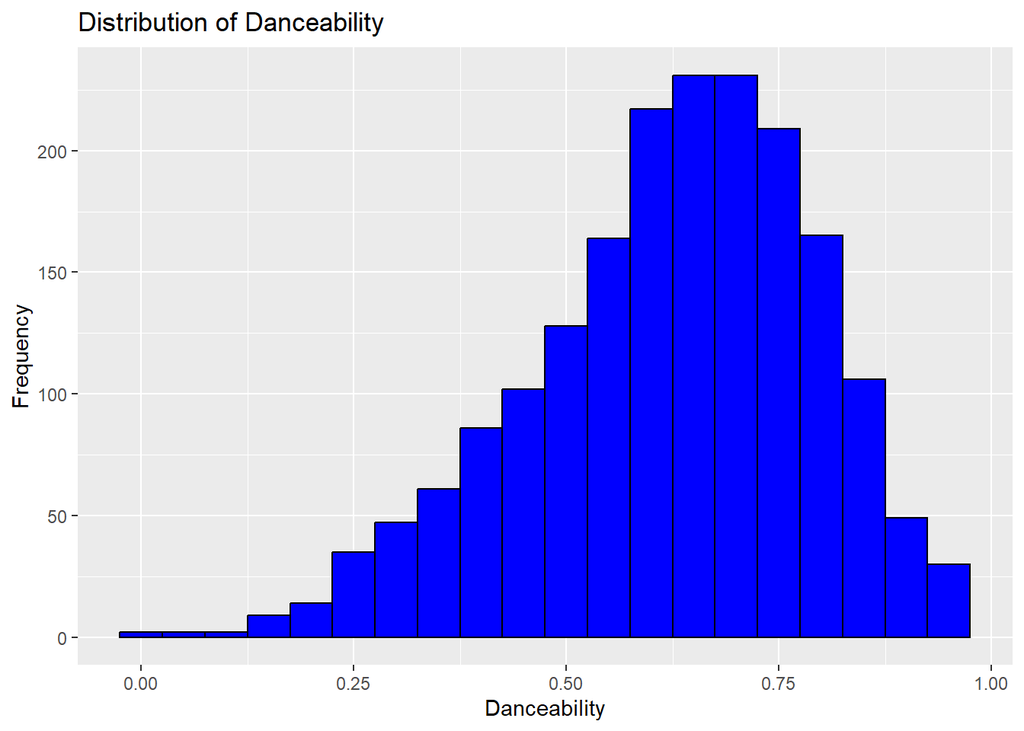

```r
ggplot(df, aes(x = Danceability)) +
  geom_histogram(binwidth = 0.05, fill = "blue", color = "black") +
  labs(title = "Distribution of Danceability", x = "Danceability", y = "Frequency")
```

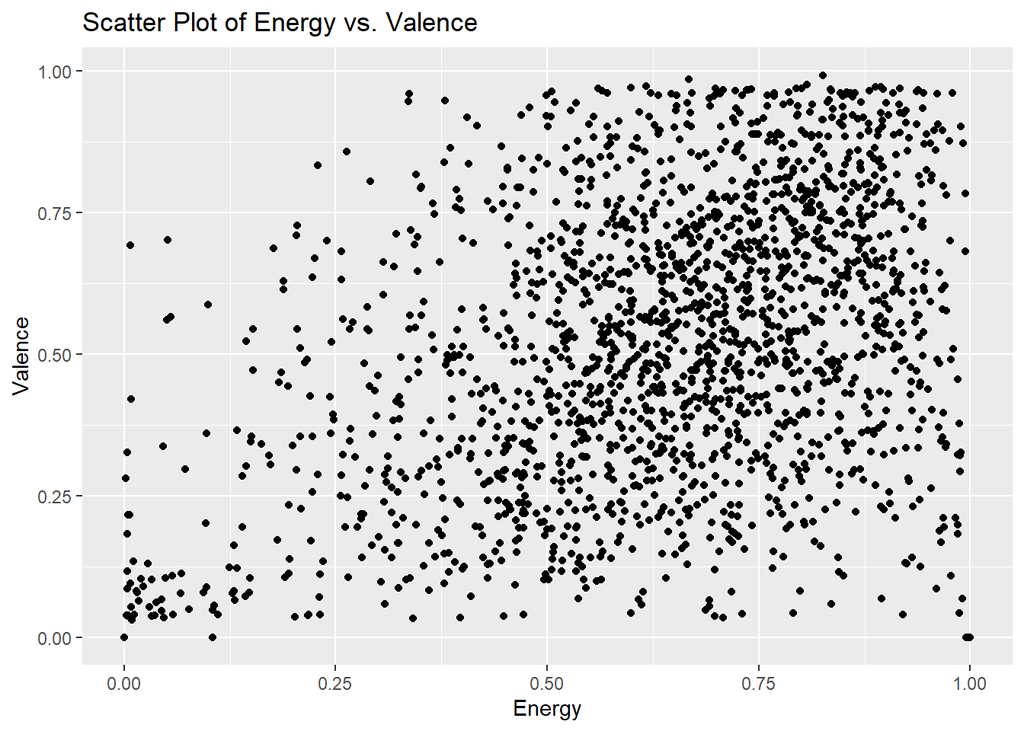

```r
ggplot(df, aes(x = Energy, y = Valence)) +
  geom_point() +
  labs(title = "Scatter Plot of Energy vs. Valence", x = "Energy", y = "Valence")
```

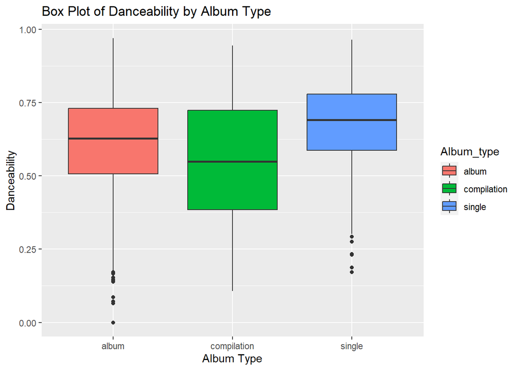

```r
# Example: Box plot of Danceability by Album Type
ggplot(df, aes(x = Album_type, y = Danceability, fill = Album_type)) +
  geom_boxplot() +
  labs(title = "Box Plot of Danceability by Album Type", x = "Album Type", y = "Danceability")
```

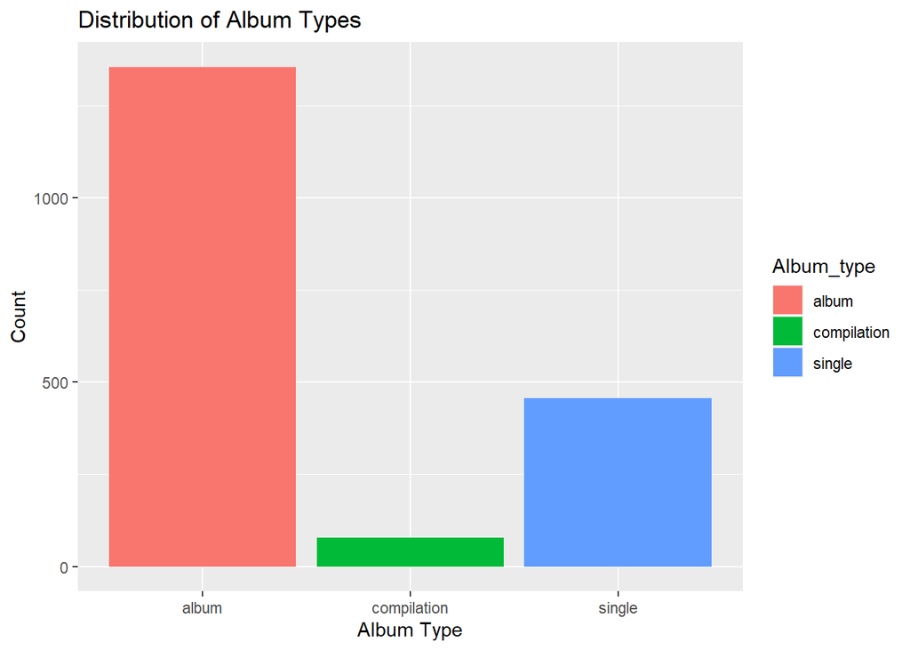

```r
ggplot(df, aes(x = Album_type, fill = Album_type)) +
  geom_bar() +
  labs(title = "Distribution of Album Types", x = "Album Type", y = "Count")
```

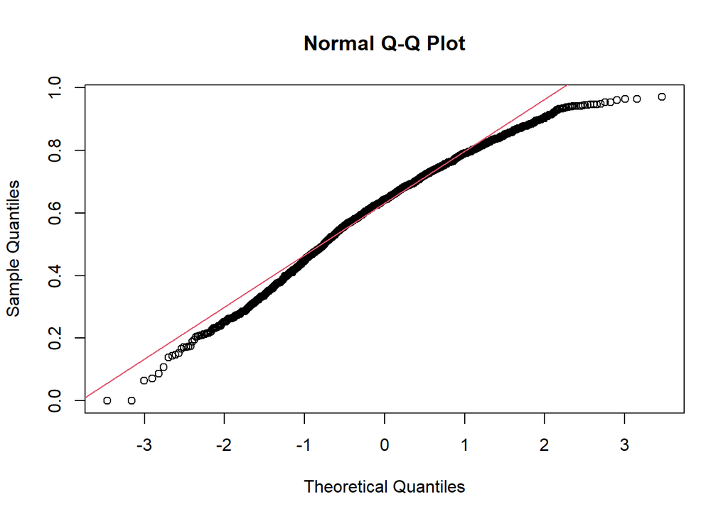

```r
# Conduct normality check for danceab
# You can replace 'Danceability' with the variable you want to check for normality

# Q-Q plot for normality check
qqnorm(df$Danceability)
qqline(df$Danceability, col = 2)
```

```r
# H0 : The data follows normal distribution.

# H1 : The data does not follow normal distribution.
df_numeric <- Filter(is.numeric,df)
df_numeric <- na.omit(df_numeric)
result <- mvn(data = df_numeric, mvnTest = "royston")
result$multivariateNormality
```

```
##      Test        H p value MVN
## 1 Royston 2541.242       0  NO
```

# Since p value is less than alpha=0.05, we reject H0 and we can say that we don’t have enough evidence to prove that the data follow normal distribution.

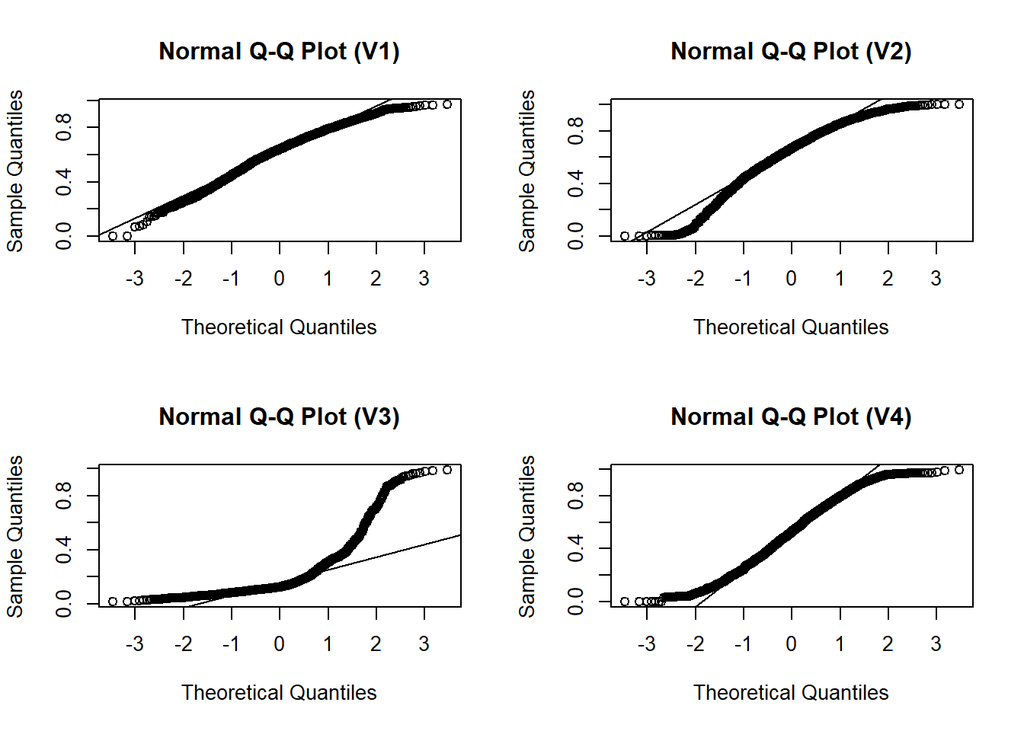

```r
# create univariate Q-Q plots
df_split=cbind(df_numeric$Danceability,df_numeric$Energy,df_numeric$Liveness,df_numeric$Valence)
result <- mvn(data = df_split, mvnTest = "royston", univariatePlot = "qqplot")
```

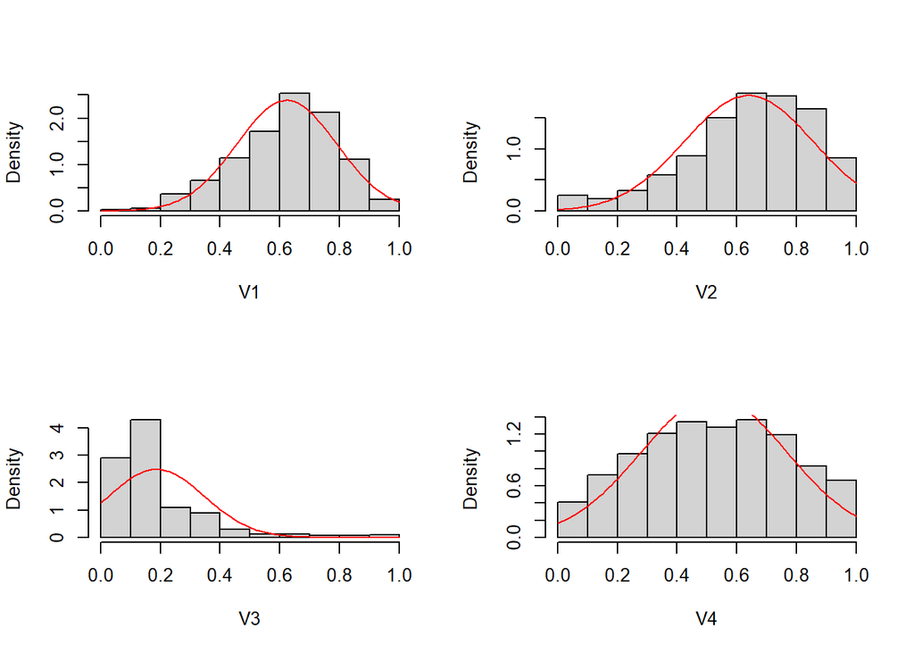

```r
# create univariate histograms
result <- mvn(data = df_split, mvnTest = "royston", univariatePlot = "histogram", univariateTest = "SW" )
```

```r
df_split <- as.data.frame(df_split)
result <- mvn(data = df_split,mvnTest = "royston",multivariateOutlierMethod = "quan")
```

[figure not shown]

# *Question 2*

```r
# Question is to check if means of Danceability and Valence are 0.7
# H0=μ=μ0 vs  H1=μ≠μ0

y <- df %>%  dplyr::select (Danceability,Valence)
xbar <- colMeans(y)
xbar
```

```
## Danceability      Valence
##    0.6226546    0.5234526
```

```r
test <- mvn(y, mvnTest = "mardia")
test$multivariateNormality
```

```
##              Test         Statistic              p value Result
## 1 Mardia Skewness  116.322719648457 3.25747068499248e-24     NO
## 2 Mardia Kurtosis -4.18047096962961 2.90905950337539e-05     NO
## 3             MVN              <NA>                 <NA>     NO
```

```r
log_y <- log(y)
log_y[log_y == -Inf] <- NA
test<-mvn(log_y,mvnTest = "mardia")
test$univariateNormality # no normality
```

```
##               Test     Variable Statistic   p value Normality
## 1 Anderson-Darling Danceability   51.7933  <0.001      NO
## 2 Anderson-Darling   Valence      82.0245  <0.001      NO
```

```r
mu_0 <- c(0.7,0.7)
HotellingsT2(y,mu=mu_0)
```

```
##
##  Hotelling's one sample T2-test
##
## data:  y
## T.2 = 514.44, df1 = 2, df2 = 1888, p-value < 2.2e-16
## alternative hypothesis: true location is not equal to c(0.7,0.7)
```

#*Since p<alpha=0.05, we reject H0. Therefore, we do not have enough evidence to conclude that mean vector equals (0.7,0.7)*

# *Q3*

# Assuming ‘Album_type’ is your grouping variable

# Example data frame structure: data.frame(Album_type, Danceability, Energy, Liveness, Valence)

```r
# MANOVA
manova_results <- manova(cbind(Danceability, Energy, Liveness, Valence) ~ Album_type, data = df)
summary(manova_results)
```

```
##              Df   Pillai approx F num Df den Df    Pr(>F)
## Album_type    2 0.059218   14.379      8   3770 < 2.2e-16 ***
## Residuals  1887
## ---
## Signif. codes:  0 '***' 0.001 '**' 0.01 '*' 0.05 '.' 0.1 ' ' 1
```

```r
summary.aov(manova_results)
```

```
##  Response Danceability :
##               Df Sum Sq Mean Sq F value   Pr(>F)
## Album_type     2  1.587 0.79340   29.24 3.12e-13 ***
## Residuals   1887 51.202 0.02713
## ---
## Signif. codes:  0 '***' 0.001 '**' 0.01 '*' 0.05 '.' 0.1 ' ' 1
##
##  Response Energy :
##               Df Sum Sq Mean Sq F value    Pr(>F)
## Album_type     2  1.329 0.66467   14.69 4.669e-07 ***
## Residuals   1887 85.378 0.04525
## ---
## Signif. codes:  0 '***' 0.001 '**' 0.01 '*' 0.05 '.' 0.1 ' ' 1
##
##  Response Liveness :
##               Df Sum Sq  Mean Sq F value Pr(>F)
## Album_type     2  0.070 0.034873   1.364 0.2559
## Residuals   1887 48.243 0.025566
##
##  Response Valence :
##               Df  Sum Sq  Mean Sq F value Pr(>F)
## Album_type     2   0.107 0.053283  0.8888 0.4113
## Residuals   1887 113.119 0.059946
```

#*These results suggest that Album_type has a significant impact on Danceability and Energy, but not on Liveness and Valence.*

```r
df_numeric <- select_if(df,is.numeric)
df_numeric = na.omit(df_numeric)
str(df_numeric)
```

```
## 'data.frame':    1890 obs. of  14 variables:
##  $ X           : int  18846 18894 2985 1841 3370 11637 6745 16127 2756 12635 ...
##  $ Danceability: num  0.896 0.786 0.631 0.669 0.737 0.751 0.598 0.562 0.323 0.784 ...
##  $ Energy      : num  0.818 0.572 0.631 0.829 0.603 0.746 0.824 0.46 0.0114 0.73 ...
##  $ Key         : num  11 11 6 1 10 2 11 5 4 1 ...
##  $ Loudness    : num  -5.67 -4.97 -6.93 -3.8 -7.49 ...
##  $ Speechiness : num  0.191 0.0399 0.0307 0.49 0.239 0.292 0.131 0.259 0.0343 0.191 ...
##  $ Liveness    : num  0.101 0.0808 0.133 0.241 0.118 0.0503 0.0975 0.107 0.171 0.107 ...
##  $ Valence     : num  0.804 0.539 0.697 0.61 0.492 0.889 0.416 0.623 0.134 0.0415 ...
##  $ Tempo       : num  90 92 90 119 76 ...
##  $ Duration_ms : num  205333 212800 263152 253067 281800 ...
##  $ Views       : num  313181 4232418 87878430 5174815 48682 ...
##  $ Likes       : num  3962 179601 478253 67542 461 ...
##  $ Comments    : num  90 2907 12162 3536 20 ...
##  $ Stream      : num  6.95e+05 2.35e+07 4.17e+07 1.02e+08 6.17e+04 ...
##  - attr(*, "na.action")= 'omit' Named int [1:110] 7 30 32 48 57 97 103 107 122 137 ...
##   ..- attr(*, "names")= chr [1:110] "4761" "3004" "7989" "14426" ...
```

```r
dim(df_numeric)
```

```
## [1] 1890   14
```

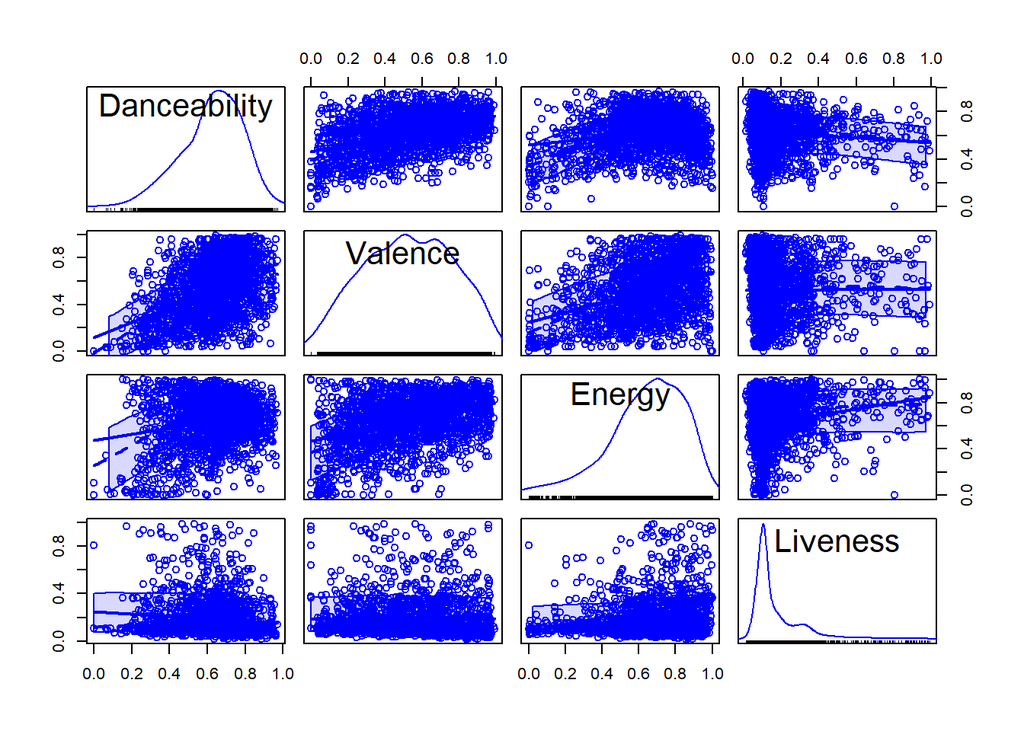

```r
df_pca <- dplyr:: select(df, c("Danceability", "Valence", "Energy", "Liveness"))
# scatter plot for correlation test to use for pca
scatterplotMatrix(df_pca, diagonal = "histogram")
```

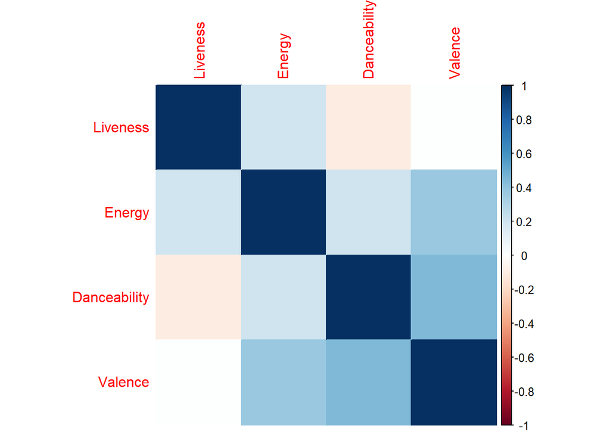

```r
library(corrplot)


# correlation of our variables and corrplot
res <- cor(df_pca,method = "pearson")
corrplot(res, method= "color", order = "hclust")
```

```r
df_pca <- scale(df_pca)
df_pca
```

[output not shown]

[output cut: 1882 more lines]

```r
# correlation of scaled data set
cor(df_pca)
```

```
##              Danceability     Valence    Energy     Liveness
## Danceability    1.0000000 0.446799508 0.2031253 -0.102530536
## Valence         0.4467995 1.000000000 0.3794897  0.008407797
## Energy          0.2031253 0.379489675 1.0000000  0.195936879
## Liveness       -0.1025305 0.008407797 0.1959369  1.000000000
```

```r
# we put a side base total that we can conduct pca
df_pca_1 <- df_pca[,-2]
# pca with prcomp function and summary
pca1 <- prcomp(df_pca_1)
summary(pca1)
```

```
## Importance of components:
##                           PC1    PC2    PC3
## Standard deviation     1.1116 1.0500 0.8136
## Proportion of Variance 0.4119 0.3675 0.2206
## Cumulative Proportion  0.4119 0.7794 1.0000
```

```r
# rotation of pca
pca1$rotation
```

```
##                    PC1         PC2        PC3
## Danceability 0.4735516 -0.68949253  0.5480410
## Energy       0.7674845  0.01776261 -0.6408214
## Liveness     0.4321069  0.72407495  0.5375864
```

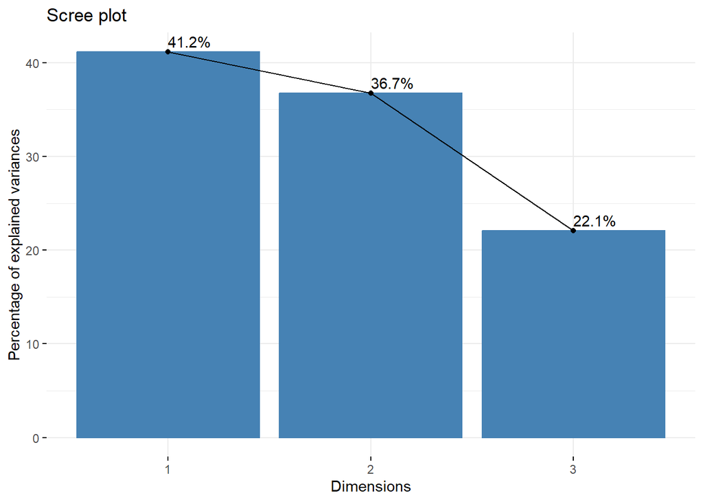

```r
fviz_eig(pca1,addlabels = TRUE)#error
```

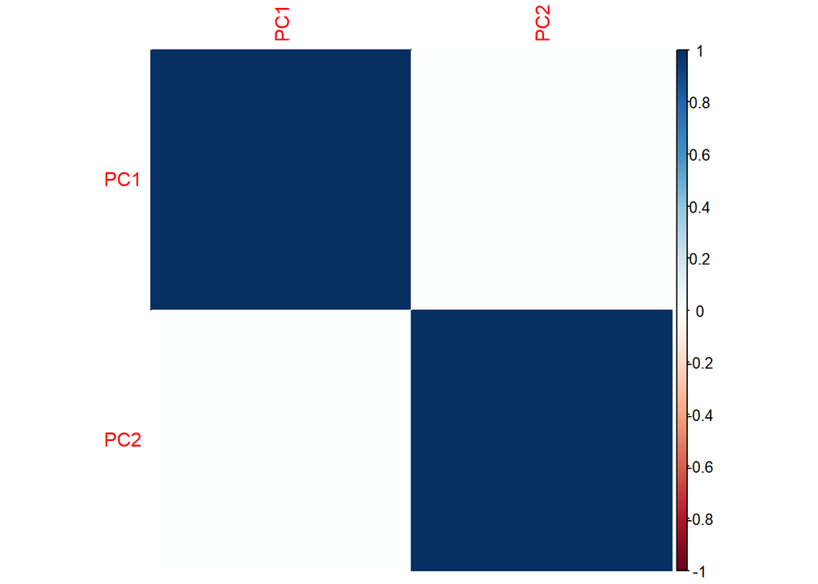

```r
# We extract first two components and continue our analysis with them
pca <- pca1$x[,1:2]
# we check that our components are linear independent
res1 <- cor(pca, method = "pearson")
corrplot(res1, method= "color", order = "hclust")
```

```r
#interpretation of pca from correlation
cor(df_pca, pca)
```

```
##                    PC1         PC2
## Danceability 0.5263985 -0.72394753
## Valence      0.4556221 -0.28118508
## Energy       0.8531334  0.01865023
## Liveness     0.4803287  0.76025809
```

```r
# principal component regression analysis


ols.data <- data.frame(base_total = df_pca[,2],pca)

lmodel <- lm(base_total ~ ., data = ols.data)

summary(lmodel)
```

```
##
## Call:
## lm(formula = base_total ~ ., data = ols.data)
##
## Residuals:
##      Min       1Q   Median       3Q      Max
## -2.62190 -0.59256 -0.00188  0.61268  2.37122
##
## Coefficients:
##               Estimate Std. Error t value Pr(>|t|)
## (Intercept) -1.148e-16  1.944e-02    0.00        1
## PC1          4.099e-01  1.749e-02   23.43   <2e-16 ***
## PC2         -2.678e-01  1.852e-02  -14.46   <2e-16 ***
## ---
## Signif. codes:  0 '***' 0.001 '**' 0.01 '*' 0.05 '.' 0.1 ' ' 1
##
## Residual standard error: 0.845 on 1887 degrees of freedom
## Multiple R-squared:  0.2867, Adjusted R-squared:  0.2859
## F-statistic: 379.1 on 2 and 1887 DF,  p-value: < 2.2e-16
```

```r
library(tidyverse)
```

– First load the data and take a quick look –

```r
df <- read.csv("C:/Users/Eren/Desktop/Stat 467/Spotify_Youtube.csv")
df <- subset(df[sample(nrow(df), 2000), ],select = -c(Acousticness,Instrumentalness))
df_numeric <- Filter(is.numeric,df)
df_numeric <- na.omit(df_numeric)
df_split=cbind(df_numeric$Danceability,df_numeric$Energy,df_numeric$Liveness,df_numeric$Valence)
colSums(is.na(df))
```

```
##              X         Artist    Url_spotify          Track          Album
##              0              0              0              0              0
##     Album_type            Uri   Danceability         Energy            Key
##              0              0              1              1              1
##       Loudness    Speechiness       Liveness        Valence          Tempo
##              1              1              1              1              1
##    Duration_ms    Url_youtube          Title        Channel          Views
##              1              0              0              0             49
##          Likes       Comments    Description       Licensed official_video
##             54             62              0              0              0
##         Stream
##             59
```

```r
df <- na.omit(df)
head(df)
```

```
##           X                       Artist
## 3285   3284 Royal Philharmonic Orchestra
## 8041   8040                         Akon
## 16463 16462                     Kodaline
## 6934   6933                 Banda Machos
## 4476   4475         Kavita Krishnamurthy
## 14983 14982              Christina Perri
##                                                  Url_spotify
## 3285  https://open.spotify.com/artist/0MvSBMGRQJY3mRwIbJsqF1
## 8041  https://open.spotify.com/artist/0z4gvV4rjIZ9wHck67ucSV
## 16463 https://open.spotify.com/artist/4BxCuXFJrSWGi1KHcVqaU4
## 6934  https://open.spotify.com/artist/7MyUjj79oHy7I8RocrtzZ2
## 4476  https://open.spotify.com/artist/6WPmTGeeoymoVlXVtsCwz7
## 14983 https://open.spotify.com/artist/7H55rcKCfwqkyDFH9wpKM6
##                                                                                           Track
```

[output cut: 62 more lines]

– Description is an unnecessary column –

```r
df$Description <- NULL
head(df)
```

```
##           X                       Artist
## 3285   3284 Royal Philharmonic Orchestra
## 8041   8040                         Akon
## 16463 16462                     Kodaline
## 6934   6933                 Banda Machos
## 4476   4475         Kavita Krishnamurthy
## 14983 14982              Christina Perri
##                                                  Url_spotify
## 3285  https://open.spotify.com/artist/0MvSBMGRQJY3mRwIbJsqF1
## 8041  https://open.spotify.com/artist/0z4gvV4rjIZ9wHck67ucSV
## 16463 https://open.spotify.com/artist/4BxCuXFJrSWGi1KHcVqaU4
## 6934  https://open.spotify.com/artist/7MyUjj79oHy7I8RocrtzZ2
## 4476  https://open.spotify.com/artist/6WPmTGeeoymoVlXVtsCwz7
## 14983 https://open.spotify.com/artist/7H55rcKCfwqkyDFH9wpKM6
##                                                                                           Track
```

[output cut: 55 more lines]

– Lets summarize data for taking a look at all variables –

```r
summary(df)
```

```
##        X            Artist          Url_spotify           Track
##  Min.   :    3   Length:1876        Length:1876        Length:1876
##  1st Qu.: 5328   Class :character   Class :character   Class :character
##  Median :10362   Mode  :character   Mode  :character   Mode  :character
##  Mean   :10504
##  3rd Qu.:15924
##  Max.   :20697
##     Album            Album_type            Uri             Danceability
##  Length:1876        Length:1876        Length:1876        Min.   :0.0000
##  Class :character   Class :character   Class :character   1st Qu.:0.5180
##  Mode  :character   Mode  :character   Mode  :character   Median :0.6395
##                                                           Mean   :0.6192
##                                                           3rd Qu.:0.7402
##                                                           Max.   :0.9700
##      Energy              Key            Loudness        Speechiness
##  Min.   :0.000055   Min.   : 0.000   Min.   :-44.761   Min.   :0.00000
##  1st Qu.:0.514500   1st Qu.: 2.000   1st Qu.: -8.755   1st Qu.:0.03508
##  Median :0.673000   Median : 6.000   Median : -6.496   Median :0.05100
##  Mean   :0.639190   Mean   : 5.336   Mean   : -7.692   Mean   :0.09622
##  3rd Qu.:0.795250   3rd Qu.: 8.000   3rd Qu.: -4.929   3rd Qu.:0.10225
##  Max.   :1.000000   Max.   :11.000   Max.   : -0.514   Max.   :0.94700
##     Liveness          Valence           Tempo         Duration_ms
##  Min.   :0.01900   Min.   :0.0000   Min.   :  0.00   Min.   : 31000
##  1st Qu.:0.09595   1st Qu.:0.3440   1st Qu.: 97.03   1st Qu.:180939
##  Median :0.12900   Median :0.5470   Median :118.98   Median :213063
##  Mean   :0.19958   Mean   :0.5350   Mean   :119.83   Mean   :222418
##  3rd Qu.:0.24325   3rd Qu.:0.7402   3rd Qu.:137.99   3rd Qu.:249236
##  Max.   :0.99000   Max.   :0.9840   Max.   :213.50   Max.   :824133
##  Url_youtube           Title             Channel              Views
##  Length:1876        Length:1876        Length:1876        Min.   :1.380e+02
##  Class :character   Class :character   Class :character   1st Qu.:2.134e+06
##  Mode  :character   Mode  :character   Mode  :character   Median :1.689e+07
##                                                           Mean   :9.928e+07
##                                                           3rd Qu.:8.208e+07
##                                                           Max.   :4.821e+09
##      Likes             Comments         Licensed         official_video
##  Min.   :       1   Min.   :      0   Length:1876        Length:1876
##  1st Qu.:   24256   1st Qu.:    558   Class :character   Class :character
##  Median :  146207   Median :   3760   Mode  :character   Mode  :character
##  Mean   :  695949   Mean   :  30054
##  3rd Qu.:  594353   3rd Qu.:  16380
##  Max.   :26399133   Max.   :5331537
##      Stream
##  Min.   :7.771e+03
##  1st Qu.:1.852e+07
##  Median :4.999e+07
##  Mean   :1.351e+08
##  3rd Qu.:1.377e+08
##  Max.   :2.595e+09
```

– Lets visualized for making a close look –

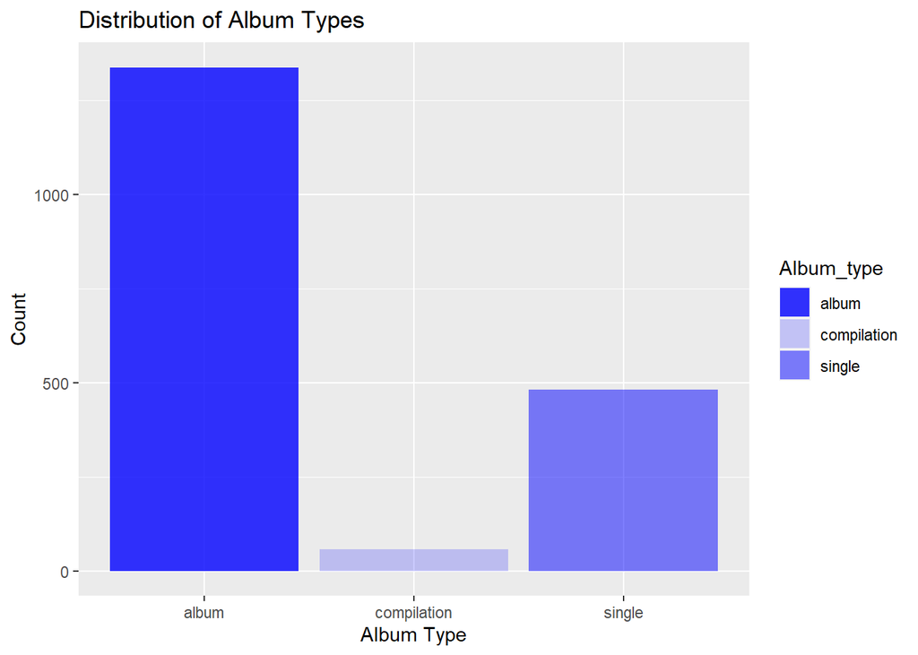

```r
library(ggplot2)
album <- ggplot(df, aes(x = Album_type, alpha = Album_type))
album <- album + geom_bar(fill = "blue")
album + labs(title = "Distribution of Album Types", x = "Album Type", y = "Count") +
  scale_alpha_manual(values = c(0.8, 0.2, 0.5))
```

– It looks like albums are more common – – Lets look at the continuous variables and their interactions – – I think we need to look at song related think and popularity think separate –

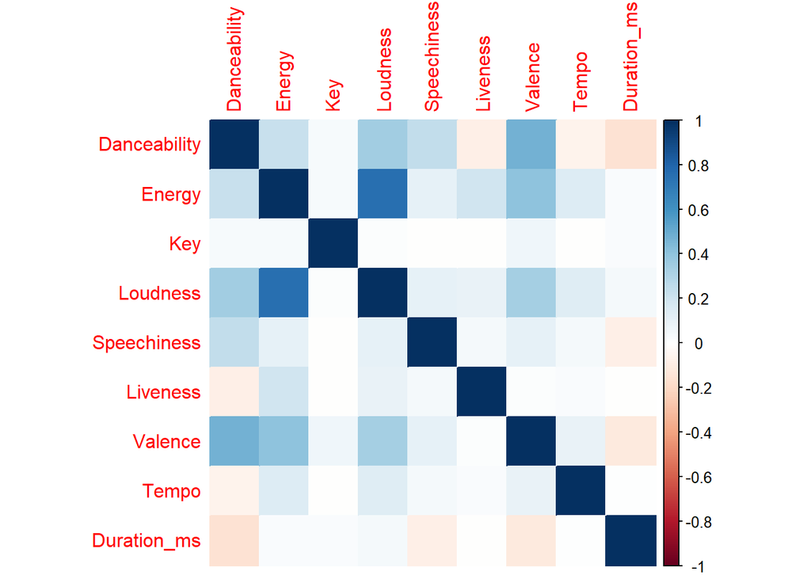

```r
library(corrplot)
cont <- sapply(df, is.numeric)
cont_data <- df[, cont]
cont_data$X <- NULL
songr <- cont_data[,0:9]
correlation1 <- cor(songr)
corrplot(correlation1, method = "color")
```

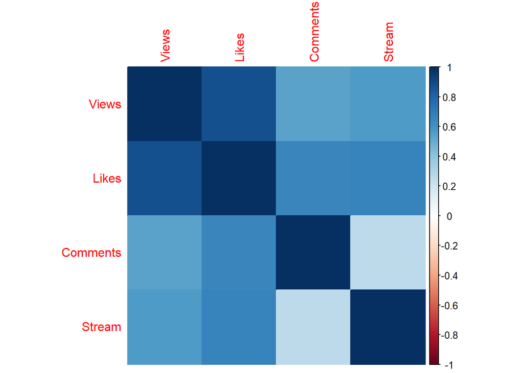

```r
popr <- cont_data[,10:13]
correlation2 <- cor(popr)
corrplot(correlation2, method = "color")
```

– Views and Likes has a really strong relationship – – Views and Likes will be dependent variables for us –

```r
dep <- popr[,0:2]
cor(dep)
```

```
##           Views     Likes
## Views 1.0000000 0.8728789
## Likes 0.8728789 1.0000000
```

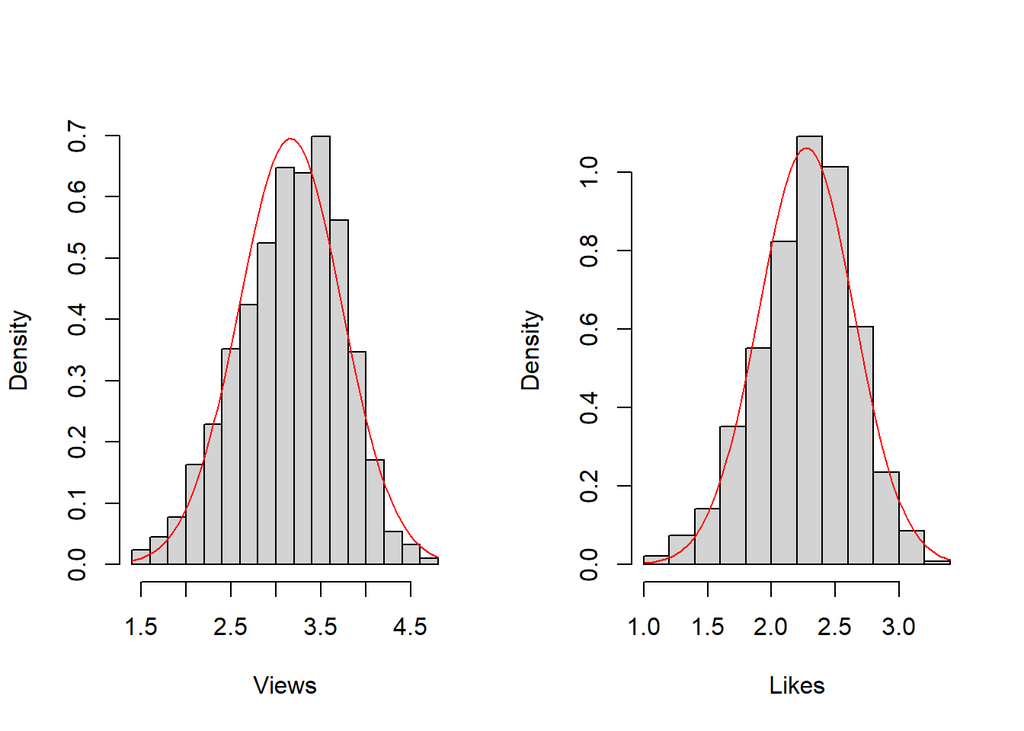

```r
library(MVN)
result_mvn <- mvn(dep, univariateTest = "AD", univariatePlot = "histogram", bc = T)
```

```r
result_mvn$univariateNormality
```

```
##               Test  Variable Statistic   p value Normality
## 1 Anderson-Darling   Views      5.4020  <0.001      NO
## 2 Anderson-Darling   Likes      3.6975  <0.001      NO
```

```r
library(bestNormalize)
```

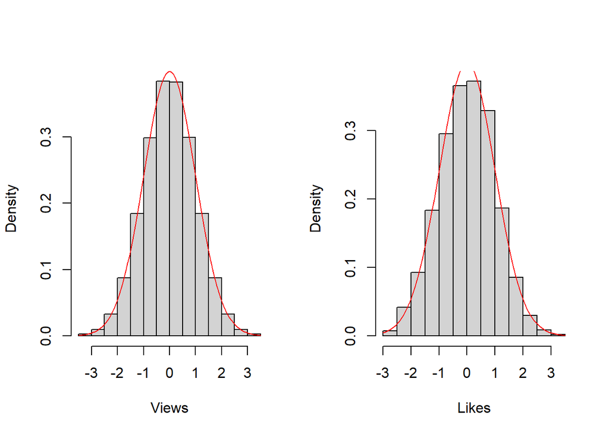

```r
normal_dep <- dep
normalized_likes <- bestNormalize(dep$Likes, allow_lambert_s = T)
normalized_likes <- predict(normalized_likes)
normal_dep$Likes <- normalized_likes
normalized_views <- bestNormalize(dep$Views, allow_lambert_s = T)
normalized_views <- predict(normalized_views)
normal_dep$Views <- normalized_views
normal_dep_scale <- scale(normal_dep)
result_mvn <- mvn(normal_dep_scale, univariateTest = "AD", univariatePlot = "histogram")
```

```r
result_mvn$univariateNormality
```

```
##               Test  Variable Statistic   p value Normality
## 1 Anderson-Darling   Views      0.0010    1.0000    YES
## 2 Anderson-Darling   Likes      0.5038    0.2041    YES
```

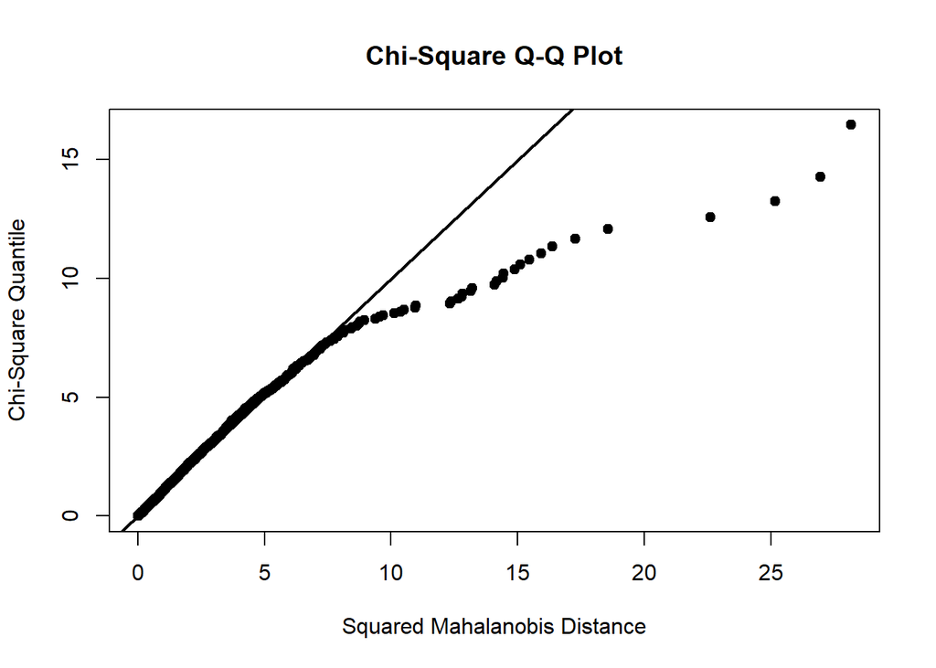

```r
result_mvn1 <- mvn(normal_dep_scale, mvnTest = "hz",multivariatePlot = "qq")
```

```r
result_mvn1$multivariateNormality
```

```
##            Test       HZ      p value MVN
## 1 Henze-Zirkler 3.959439 1.912348e-11  NO
```

##### We could not normalize our data but we will assume that our data follow multivariate normal

```r
library(psych)
# first scaled data because factor analysis sensitive for different scales
normal_dep_scale <- as.data.frame(normal_dep_scale)
spotify <- songr
spotify <- spotify[,-3]
spotify_scaled <- scale(spotify)
spotify_scaled <- cbind(normal_dep_scale,spotify)
spotify_scaled <- as.data.frame(spotify_scaled)
```

```r
factor_analysis1 <- fa(spotify_scaled[, c("Views", "Likes")], rotate = "varimax",nfactors = 1)
summary(factor_analysis1)
```

```
##
## Factor analysis with Call: fa(r = spotify_scaled[, c("Views", "Likes")], nfactors = 1, rotate = "varimax")
##
## Test of the hypothesis that 1 factor is sufficient.
## The degrees of freedom for the model is -1  and the objective function was  0
## The number of observations was  1876  with Chi Square =  0  with prob <  NA
##
## The root mean square of the residuals (RMSA) is  0
## The df corrected root mean square of the residuals is  NA
##
## Tucker Lewis Index of factoring reliability =  1
```

##### This summary shows that. The df for model is -1 and objective function was 0 so this shows good fit for model. Chi-square = 0 means that model fits the data well. The root means square (RMSA) is 0 too it shows perfect fit this means that model could use the spotify_scaled data to explain observed variance without any residuals. The Tucker Lewis is 1 it shows high reliability.

```r
factor_analysis1$loadings
```

```
##
## Loadings:
##       MR1
## Views 0.981
## Likes 0.981
##
##                  MR1
## SS loadings    1.924
## Proportion Var 0.962
```

```r
factor_analysis2 <- fa(spotify_scaled[, c("Views", "Likes")], rotate = "promax",nfactors = 1)
summary(factor_analysis2)
```

```
##
## Factor analysis with Call: fa(r = spotify_scaled[, c("Views", "Likes")], nfactors = 1, rotate = "promax")
##
## Test of the hypothesis that 1 factor is sufficient.
## The degrees of freedom for the model is -1  and the objective function was  0
## The number of observations was  1876  with Chi Square =  0  with prob <  NA
##
## The root mean square of the residuals (RMSA) is  0
## The df corrected root mean square of the residuals is  NA
##
## Tucker Lewis Index of factoring reliability =  1
```

```r
factor_analysis2$loadings
```

```
##
## Loadings:
##       MR1
## Views 0.981
## Likes 0.981
##
##                  MR1
## SS loadings    1.924
## Proportion Var 0.962
```

##### same for both rotation I will use “varimax” which means orthogonal because it is more simple

```r
factor_analysis_all <- factanal(spotify_scaled, rotation = "varimax",factors = 1)
print(factor_analysis_all)
```

```
##
## Call:
## factanal(x = spotify_scaled, factors = 1, rotation = "varimax")
##
## Uniquenesses:
##        Views        Likes Danceability       Energy     Loudness  Speechiness
##        0.019        0.057        0.976        0.960        0.911        1.000
##     Liveness      Valence        Tempo  Duration_ms
##        1.000        0.994        0.996        0.985
##
## Loadings:
##              Factor1
## Views         0.990
## Likes         0.971
## Danceability  0.154
## Energy        0.199
## Loudness      0.299
## Speechiness
## Liveness
## Valence
## Tempo
## Duration_ms   0.123
##
##                Factor1
## SS loadings      2.102
## Proportion Var   0.210
##
## Test of the hypothesis that 1 factor is sufficient.
## The chi square statistic is 3015.79 on 35 degrees of freedom.
## The p-value is 0
```

##### Since my primary focus is “Views” and “Likes” and 1 factor model for specificly “Views” and “Likes” gaves more information about my focus I will use that model.

```r
subset_ind <- subset(spotify_scaled[,3:10])
subset_res <- subset(spotify_scaled[,1:2])
kmeans_res <- kmeans(subset_res, centers = 2, nstart = 25)
subset_res_c <- kmeans_res$cluster
print(table(subset_res_c))
```

```
## subset_res_c
##   1   2
## 911 965
```

```r
library(MASS)
subset_all <- cbind(subset_ind, Cluster = subset_res_c)
lda_all <- lda(Cluster ~ . , data = subset_all)
summary(lda_all)
```

```
##         Length Class  Mode
## prior    2     -none- numeric
## counts   2     -none- numeric
## means   16     -none- numeric
## scaling  8     -none- numeric
## lev      2     -none- character
## svd      1     -none- numeric
## N        1     -none- numeric
## call     3     -none- call
## terms    3     terms  call
## xlevels  0     -none- list
```